# Diversity analysis

ISME Latin America

06 October, 2021

# 1 `phyloseq` and diversity analysis introduction

## 1.1 Packages needed

First, we’ll make vectors with the names of the necessary packages.

```r
#the packages immediately available in CRAN
cran_packages <- c("bookdown", "knitr", "tidyverse", "plyr", "grid", "gridExtra", "kableExtra", "xtable", "ggpubr")
#the ones that use Bioconductor
bioc_packages <- c("phyloseq", "dada2", "DECIPHER", "phangorn", "ggpubr", "BiocManager","DESeq2", "microbiome", "philr")
#packages that are still in GitHub
git_source <- c("twbattaglia/btools", "gmteunisse/Fantaxtic", "MadsAlbertsen/ampvis2", "opisthokonta/tsnemicrobiota")# fuente/nombre del paquete
git_packages <- c("btools", "fantaxtic", "ampvis2", "tsnemicrobiota") # nombre del paquete
```

Now we install the packages. JUST RUN IT ONCE, AFTER DOWNLOADING, DON’T EXECUTE AGAIN.

```
# CRAN
.inst <- cran_packages %in% installed.packages()#The %in% operator in R can be used to identify if an element (e.g., a number) belongs to a vector or dataframe
if(any(!.inst)) {
  install.packages(cran_packages[!.inst])
}
#BioConductor
if (!requireNamespace("BiocManager", quietly = TRUE))
    install.packages("BiocManager")
.inst <- bioc_packages %in% installed.packages()
if(any(!.inst)) {
  BiocManager::install(bioc_packages[!.inst])
}
#GitHub
.inst <- git_source %in% installed.packages()
if(any(!.inst)) {
  devtools::install_github(git_source[!.inst])
}
```

Now let’s load the packages.

```r
sapply(c(cran_packages, bioc_packages, git_packages), require, character.only = TRUE) #had a little trouble with phlir
```

```
##       bookdown          knitr      tidyverse           plyr           grid
##           TRUE           TRUE           TRUE           TRUE           TRUE
##      gridExtra     kableExtra         xtable         ggpubr       phyloseq
##           TRUE           TRUE           TRUE           TRUE           TRUE
##          dada2       DECIPHER       phangorn         ggpubr    BiocManager
##           TRUE           TRUE           TRUE           TRUE           TRUE
##         DESeq2     microbiome          philr         btools      fantaxtic
##           TRUE           TRUE          FALSE           TRUE           TRUE
##        ampvis2 tsnemicrobiota
##           TRUE           TRUE
```

## 1.2 What can we do with `phyloseq`

`Phyloseq`is a package from Bioconductor for analysis and manipulation of metagenomic data obtained from high yield sequencing. It allows us to save, import, analyze and visualize the sequencing data after being processed in the first place as in obtaining the ASVs or OTUs, including associated data, associated observation tables of each sample, phylogeny, or taxonomic identification. The objects produced have four components that store the read count, the metadata, taxonomy, and phylogenetic trees. We can see a complete diagram of `phyloseq` in this image.

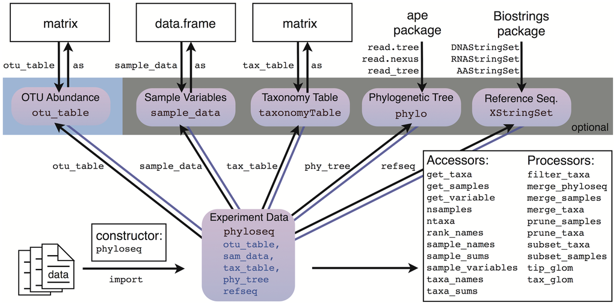

## 1.3 Start working with the data

First, we’ll use the `phyloseq`object called `ps`. If you don’t have a `ps` object, you can download it from [here](https://www.dropbox.com/s/df1aie9angv16gk/ps.RDS?dl=0).

```r
psd <- readRDS("C:/Users/fotgo/Downloads/ps.RDS") #CHANGE ME to directory with the object
psd
```

```
## phyloseq-class experiment-level object
## otu_table()   OTU Table:         [ 1476 taxa and 98 samples ]
## sample_data() Sample Data:       [ 98 samples by 13 sample variables ]
## tax_table()   Taxonomy Table:    [ 1476 taxa by 6 taxonomic ranks ]
## phy_tree()    Phylogenetic Tree: [ 1476 tips and 1474 internal nodes ]
```

# 2 Quality control of 16S analysis

We check for the prevalence of the taxonomic features.

We create a data frame with the prevalence values, then we add the taxonomy and we graph.

```r
prevdf <- apply(X = otu_table(psd),#the otu table from the psd object
               MARGIN = ifelse(taxa_are_rows(psd), yes = 1, no = 2),
               FUN = function(x){sum(x > 0)})#gives the prevalence of the otu table

prevdf <- data.frame(Prevalence = prevdf,
                    TotalAbundance = taxa_sums(psd),
                    tax_table(psd))#creates the object with the prevalence of the otu table and the taxa names of each one, also de abundance

plyr::ddply(prevdf, "Phylum", function(df1){cbind(mean(df1$Prevalence),sum(df1$Prevalence))}) -> dfprev #subsets the data from the data frame that was previously created and shows the phylum and the mean of the prevalence and the sum of said prevalence
kable(dfprev)#puts the data in a more attractive table
```

| Phylum | 1 | 2 |
| --- | --- | --- |
| Acidobacteria | 3.800000 | 38 |
| Actinobacteria | 5.041667 | 363 |
| Bacteroidetes | 5.719388 | 2242 |
| BRC1 | 1.000000 | 1 |
| Chloroflexi | 1.750000 | 21 |
| Ciliophora | 3.000000 | 9 |
| Cyanobacteria | 4.223881 | 283 |
| Deinococcus-Thermus | 1.333333 | 4 |
| Epsilonbacteraeota | 2.760000 | 69 |
| Euryarchaeota | 3.714286 | 26 |
| Firmicutes | 4.685315 | 670 |
| Fusobacteria | 3.500000 | 70 |
| Gemmatimonadetes | 1.000000 | 2 |
| Kiritimatiellaeota | 1.000000 | 1 |
| Lentisphaerae | 1.250000 | 5 |
| Marinimicrobia_(SAR406_clade) | 3.500000 | 7 |
| Nanoarchaeaeota | 1.000000 | 1 |
| Nitrospinae | 1.000000 | 1 |
| Ochrophyta | 1.000000 | 1 |
| Patescibacteria | 5.473684 | 312 |
| Planctomycetes | 3.235294 | 110 |
| Proteobacteria | 8.233840 | 4331 |
| Schekmanbacteria | 1.000000 | 1 |
| Spirochaetes | 1.500000 | 3 |
| Tenericutes | 6.083333 | 73 |
| Thaumarchaeota | 4.000000 | 12 |
| Verrucomicrobia | 4.814815 | 130 |
| NA | 6.425532 | 302 |

## 2.1 Filter the undesired taxa

```r
# Here we define which taxa we're going to take out, they are completely arbitrary
filterPhyla <- c("BRC1", "Deinococcus-Thermus", "Gemmatimonadetes", "Kiritimatiellaeota", "Nanoarchaeaeota", "Ochrophyta", "Schekmanbacteria", "Ciliophora", "Spirochaetes", NA)

# The actual filter
(psd1 <- subset_taxa(psd, !Phylum %in% filterPhyla))
```

```
## phyloseq-class experiment-level object
## otu_table()   OTU Table:         [ 1414 taxa and 98 samples ]
## sample_data() Sample Data:       [ 98 samples by 13 sample variables ]
## tax_table()   Taxonomy Table:    [ 1414 taxa by 6 taxonomic ranks ]
## phy_tree()    Phylogenetic Tree: [ 1414 tips and 1412 internal nodes ]
```

```r
# We also filter reads that correspond to thins that aren't microorganisms

filterPhyla2 <- c("Chloroplast", "Mitochondria", "Eukaryota")
psd1 <- subset_taxa(psd1, !Kingdom %in% filterPhyla2)
psd1 <- subset_taxa(psd1, !Phylum %in% filterPhyla2)
psd1 <- subset_taxa(psd1, !Class %in% filterPhyla2)
psd1 <- subset_taxa(psd1, !Order %in% filterPhyla2)
psd1 <- subset_taxa(psd1, !Family %in% filterPhyla2)
psd1 <- subset_taxa(psd1, !Genus %in% filterPhyla2)
```

We can also make other types of sub-setting the data. We can filter based on the mean read counts, with their distribution, and filtering samples with a low number of minimum reads.

```r
# Filtered based on an arbitrary threshold of the mean read count, in this case we select 1e-5
psd2 <- filter_taxa(psd1, function(x) mean(x) > 1e-5, TRUE)

# We can also remove those thaxa that are not observed an X amount of times at least in 10% of the samples
psd3 <- filter_taxa(psd2, function(x) sum(x > 2) > (0.1*length(x)), TRUE)

# Finally, we can filter samples with less of an arbitrary number, in this case 1000 reads
psd4 <- prune_samples(sample_sums(psd3) > 1000, psd3)

psd4
```

```
## phyloseq-class experiment-level object
## otu_table()   OTU Table:         [ 136 taxa and 87 samples ]
## sample_data() Sample Data:       [ 87 samples by 13 sample variables ]
## tax_table()   Taxonomy Table:    [ 136 taxa by 6 taxonomic ranks ]
## phy_tree()    Phylogenetic Tree: [ 136 tips and 135 internal nodes ]
```

Now, we can filter even more if we desire. The next filter is based on a threshold and then visualizing the effect graphically.

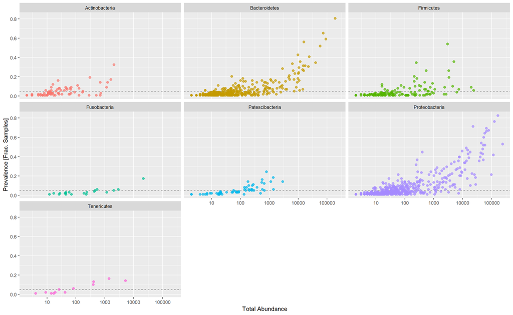

```r
# Selecting taxa
prevdf1 <- subset(prevdf, Phylum %in% get_taxa_unique(psd4, "Phylum"))
ggplot(prevdf1, aes(TotalAbundance, Prevalence / nsamples(psd),color=Phylum)) +
# A line for it to be clearer
  geom_hline(yintercept = 0.05, alpha = 0.5, linetype = 2) +  geom_point(size = 2, alpha = 0.7) +
  scale_x_log10() +  xlab("Total Abundance") + ylab("Prevalence [Frac. Samples]") +
  facet_wrap(~Phylum) + theme(legend.position="none")
```

```r
# We define the prevalence threshold at 5%
prevalenceThreshold <- 0.05 * nsamples(psd4)
```

```r
# Execute prevalence filter, using `prune_taxa()` function
keepTaxa <- rownames(prevdf1)[(prevdf1$Prevalence >= prevalenceThreshold)]
psd5 <- prune_taxa(keepTaxa, psd4)
```

While we use ``DADA2```, the taxa sequence or ASV is determined, but in this case we’ll just work at community level. For this purpose the names will be changed with correlative codes for better understanding down the line.

```r
# Change the sequences for a generic name
taxa_names(psd5) <- paste0("ASV", seq(ntaxa(psd5)))
```

Now that the reads have been filtered, our `phyloseq` object is ready for use and can be visualized. First we’ll graph the read counts by sample so that we can have an idea of their distribution.

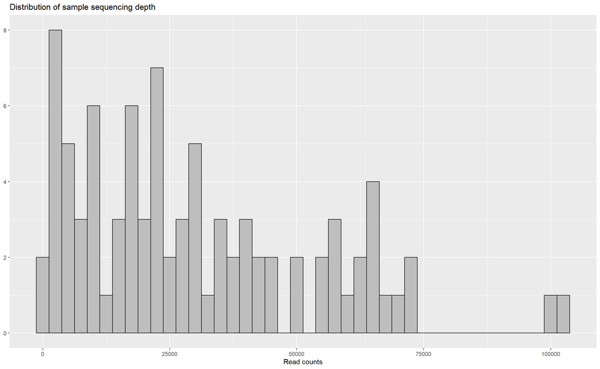

```r
#make a data frame with the sums of the read counts
sample_sum_df <- data.frame(sum <- sample_sums(psd5))

#graph
ggplot(sample_sum_df, aes(x = sum)) +
  geom_histogram(color = "black", fill = "grey", binwidth = 2500) +
  ggtitle("Distribution of sample sequencing depth") +
  xlab("Read counts") +
  theme(axis.title.y = element_blank())
```

Finally, we calculate the rarefaction curve for each sample, so that we can determine if the sequencing was enough or if more sequencing is needed. This analysis let us estimate if we could find more OTUs or ASVs if more sequencing is done.

```r
# Loading some previously done scripts
scripts <- c("graphical_methods.R",
             "tree_methods.R",
             "plot_merged_trees.R",
             "specificity_methods.R",
             "ternary_plot.R",
             "richness.R",
             "edgePCA.R",
             "copy_number_correction.R",
             "import_frogs.R",
             "prevalence.R",
             "compute_niche.R")
urls <- paste0("https://raw.githubusercontent.com/mahendra-mariadassou/phyloseq-extended/master/R/", scripts)

for (url in urls) {
  source(url)
}
```

Now we graph.

```r
p <- ggrare(psd5, step = 100, color = "species", label = "sample_ID", se = TRUE)
```

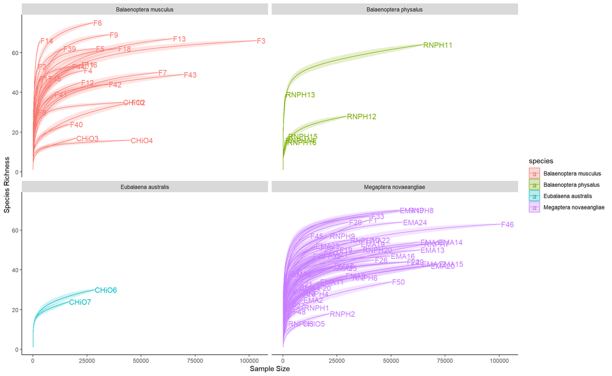

```r
(p <- p + facet_wrap(~species))+theme(
    panel.border = element_blank(),
    panel.grid.major = element_blank(),
    panel.grid.minor = element_blank(),
    panel.background = element_blank(),
    axis.line = element_line(colour = "black"))
```

# 3 Structure and manipulation of a `phyloseq`object

Some times we want to analyse a subset of the samples in our `phyloseq`object, or rather, we want to select certain taxonomic groups for future analysis. `phyloseq`allows us to make a variety of filters in order to do so. We’ll first visualize the table with the information from our `phyloseq`object.

```r
#read count table
kable(head(otu_table(psd5)), "html") %>%
    kable_styling() %>%
    scroll_box(width = "800px", height = "300px")
```

|  | ASV1 | ASV2 | ASV3 | ASV4 | ASV5 | ASV6 | ASV7 | ASV8 | ASV9 | ASV10 | ASV11 | ASV12 | ASV13 | ASV14 | ASV15 | ASV16 | ASV17 | ASV18 | ASV19 | ASV20 | ASV21 | ASV22 | ASV23 | ASV24 | ASV25 | ASV26 | ASV27 | ASV28 | ASV29 | … |
| --- | --- | --- | --- | --- | --- | --- | --- | --- | --- | --- | --- | --- | --- | --- | --- | --- | --- | --- | --- | --- | --- | --- | --- | --- | --- | --- | --- | --- | --- | --- |
| SRR6442697 | 0 | 3 | 1 | 4 | 0 | 0 | 5 | 17 | 3 | 0 | 0 | 0 | 1 | 1 | 917 | 1031 | 0 | 3 | 0 | 76 | 0 | 0 | 3 | 0 | 0 | 0 | 0 | 0 | 0 | … |
| SRR6442698 | 0 | 9 | 537 | 2 | 0 | 0 | 4 | 0 | 8 | 4 | 0 | 0 | 2 | 1 | 2015 | 120 | 0 | 0 | 0 | 36 | 1 | 0 | 2 | 0 | 0 | 1 | 0 | 0 | 0 | … |
| SRR6442699 | 0 | 581 | 0 | 0 | 1 | 0 | 2 | 3 | 6 | 0 | 8 | 0 | 1 | 0 | 2461 | 7 | 0 | 0 | 0 | 1400 | 0 | 0 | 0 | 0 | 0 | 0 | 0 | 0 | 0 | … |
| SRR6442700 | 2 | 8300 | 3828 | 0 | 1 | 0 | 275 | 0 | 9 | 3557 | 8 | 0 | 3324 | 0 | 741 | 1045 | 413 | 6923 | 0 | 253 | 48 | 0 | 1 | 0 | 0 | 0 | 0 | 1 | 0 | … |
| SRR6442701 | 0 | 80 | 526 | 2 | 1 | 88 | 0 | 25 | 249 | 2425 | 182 | 0 | 8 | 0 | 215 | 8 | 7742 | 2455 | 6 | 565 | 9 | 0 | 0 | 0 | 0 | 0 | 0 | 0 | 0 | … |
| SRR6442702 | 0 | 6 | 49 | 13341 | 3 | 0 | 3583 | 1 | 13608 | 5 | 0 | 0 | 15 | 460 | 3 | 272 | 19137 | 14544 | 0 | 18 | 2 | 0 | 1 | 1 | 3 | 90 | 0 | 1 | 0 | … |

The OTU table shows the relationship of the name of the taxa with the samples and the mapped reads against said reads. Here the read count is directly proportional to the number of times a taxon is observed. We’ll see now the taxonomy table.

```r
#taxonomy table
kable(head(tax_table(psd5)), "html") %>%
    kable_styling() %>%
    scroll_box(width = "800px", height = "300px")
```

|  | Kingdom | Phylum | Class | Order | Family | Genus |
| --- | --- | --- | --- | --- | --- | --- |
| ASV1 | Bacteria | Proteobacteria | Gammaproteobacteria | Cardiobacteriales | Cardiobacteriaceae | NA |
| ASV2 | Bacteria | Bacteroidetes | Bacteroidia | Flavobacteriales | Flavobacteriaceae | NA |
| ASV3 | Bacteria | Proteobacteria | Gammaproteobacteria | Pseudomonadales | Moraxellaceae | NA |
| ASV4 | Bacteria | Proteobacteria | Gammaproteobacteria | NA | NA | NA |
| ASV5 | Bacteria | Proteobacteria | Gammaproteobacteria | Xanthomonadales | Xanthomonadaceae | Stenotrophomonas |
| ASV6 | Bacteria | Proteobacteria | Gammaproteobacteria | Pseudomonadales | Moraxellaceae | Moraxella |

The tax table shows the relationship between the taxa and their taxonomic lineage, i.e., it links a sequence variance, or ASV, with the taxonomic levels from kingdom all the way to genus or species, depending on the resolution level of the analysis. Now we’ll visualize metadata from our object.

```r
#metadata table
kable(head(sample_data(psd5)), "html") %>%
    kable_styling() %>%
    scroll_box(width = "800px", height = "300px")
```

| x |
| --- |
| EMA4 |
| EMA3 |
| EMA2 |
| EMA19 |
| EMA21 |
| EMA20 |

| x |
| --- |
| PRJNA428495 |
| PRJNA428495 |
| PRJNA428495 |
| PRJNA428495 |
| PRJNA428495 |
| PRJNA428495 |

| x |
| --- |
| SRP128093 |
| SRP128093 |
| SRP128093 |
| SRP128093 |
| SRP128093 |
| SRP128093 |

| x |
| --- |
| SAMN08292292 |
| SAMN08292291 |
| SAMN08292284 |
| SAMN08292283 |
| SAMN08292286 |
| SAMN08292285 |

| x |
| --- |
| SRX3533985 |
| SRX3533984 |
| SRX3533983 |
| SRX3533982 |
| SRX3533981 |
| SRX3533980 |

| x |
| --- |
| SRR6442697 |
| SRR6442698 |
| SRR6442699 |
| SRR6442700 |
| SRR6442701 |
| SRR6442702 |

| x |
| --- |
| SRS2809259 |
| SRS2809258 |
| SRS2809257 |
| SRS2809256 |
| SRS2809255 |
| SRS2809254 |

| x |
| --- |
| Chile: Estrecho_Magallanes |
| Chile: Estrecho_Magallanes |
| Chile: Estrecho_Magallanes |
| Chile: Estrecho_Magallanes |
| Chile: Estrecho_Magallanes |
| Chile: Estrecho_Magallanes |

| x |
| --- |
| 2017 |
| 2017 |
| 2017 |
| 2017 |
| 2017 |
| 2017 |

| x |
| --- |
| skin |
| skin |
| skin |
| skin |
| skin |
| skin |

| x |
| --- |
| Megaptera novaeangliae |
| Megaptera novaeangliae |
| Megaptera novaeangliae |
| Megaptera novaeangliae |
| Megaptera novaeangliae |
| Megaptera novaeangliae |

| x |
| --- |
| humpback whale |
| humpback whale |
| humpback whale |
| humpback whale |
| humpback whale |
| humpback whale |

| x |
| --- |
| 501 |
| 500 |
| 501 |
| 500 |
| 499 |
| 500 |

Finally, in this case the `phyloseq`object includes a phylogenetic tree. This tree shows the evolutionary relationships among the samples’ taxa. It may not always be present since when sequencing a universal probe may be absent, so there is no phylogeny. Now we plot the tree.

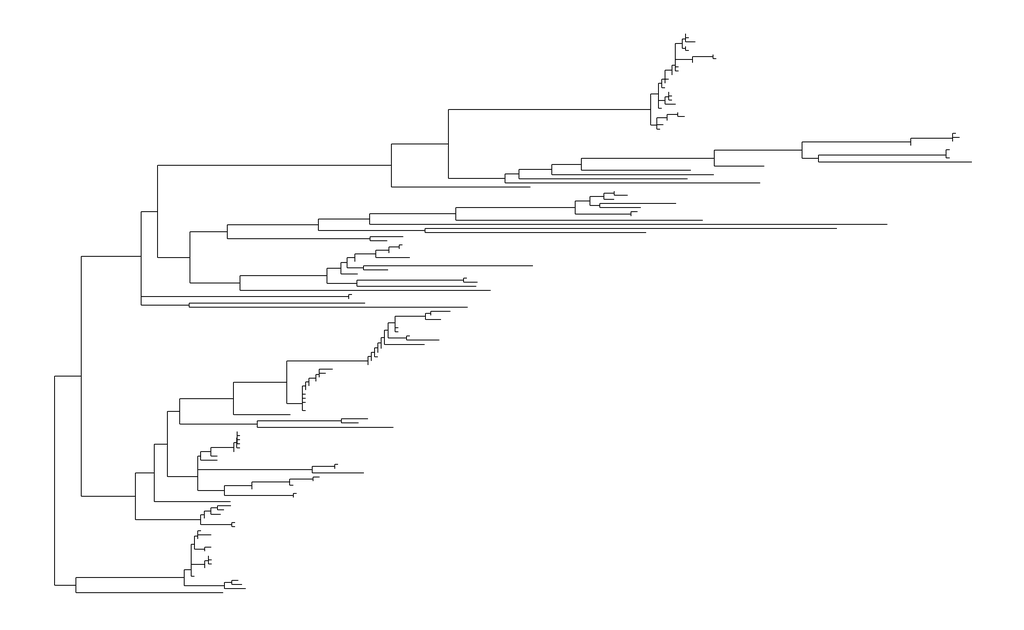

```r
# tree from our  phyloseq object
plot_tree(psd5, method = "treeonly", ladderize = "left")
```